# Slope Stability Analysis

### DataSet Link: https://www.kaggle.com/datasets/ziya07/slope-stability-analysis-dataset

# Python Librariers Requrired

```python
import numpy as np
import pandas as pd
import matplotlib.pyplot as plt
from xgboost import XGBRegressor
import seaborn as sns
from sklearn.model_selection import train_test_split
from sklearn.metrics import r2_score,mean_squared_error
```

### Dataset Features:

- **Unit Weight**
- **Cohesion**
- **Internal Friction Angle**
- **Slope Angle**
- **Slope Height**
- **Pore Water Pressure Ratio**
- **Reinforcement Type** (both categorical and numeric versions are provided)

### Potential Applications:

- **Geotechnical Engineering:** Predicting the risk of slope failure.
- **Machine Learning:** Training models to predict slope stability.
- **Civil and Environmental Engineering:** Optimizing reinforcement strategies for slopes.

The data is available in a single CSV file named `slope_stability_dataset.csv`.

```python
df = pd.read_csv("slope_stability_dataset.csv")
```

```python
df.head()
```

|  | Unit Weight (kN/m³) | Cohesion (kPa) | Internal Friction Angle (°) | Slope Angle (°) | Slope Height (m) | Pore Water Pressure Ratio | Reinforcement Type | Reinforcement Numeric | Factor of Safety (FS) |
| --- | --- | --- | --- | --- | --- | --- | --- | --- | --- |
| 0 | 18.745401 | 21.813837 | 38.249958 | 41.907228 | 18.451042 | 0.847237 | Drainage | 3 | 2.613692 |
| 1 | 24.507143 | 19.981044 | 24.612800 | 32.964623 | 9.266800 | 0.494517 | Geosynthetics | 2 | 2.241626 |
| 2 | 22.319939 | 12.926926 | 28.665992 | 58.224926 | 10.686165 | 0.195466 | Retaining Wall | 0 | 1.568244 |
| 3 | 20.986585 | 32.327000 | 36.582016 | 20.948923 | 13.130201 | 0.736642 | Drainage | 3 | 3.000000 |
| 4 | 16.560186 | 26.448087 | 32.052234 | 39.392821 | 14.164400 | 0.418678 | Soil Nailing | 1 | 3.000000 |

**Slope reinforcement** involves adding materials or structures to soil to improve its strength and prevent landslides. It's like adding rebar to concrete to make it stronger.

Here's what the types in our dataset mean:

- **Retaining Wall (0):** A solid wall built at the base of a slope to physically hold the soil back.
- **Soil Nailing (1):** Long steel bars ("nails") are drilled into the slope to pin the soil layers together, creating a more stable mass.
- **Geosynthetics (2):** Fabric-like materials (geogrids or geotextiles) are placed in horizontal layers within the soil to add tensile strength and hold it together.
- **Drainage (3):** Systems of pipes or trenches are used to remove excess water from the soil, which is a primary cause of slope failure.

```python
Reinforecement_Type = df['Reinforcement Type'].unique()
Reinforcement_Numeric = df['Reinforcement Numeric'].unique()
temp_df = pd.DataFrame(data = {"Reinforcement Type": Reinforecement_Type, "Reinforcement_Numeric": Reinforcement_Numeric})
temp_df.head()
```

|  | Reinforcement Type | Reinforcement_Numeric |
| --- | --- | --- |
| 0 | Drainage | 3 |
| 1 | Geosynthetics | 2 |
| 2 | Retaining Wall | 0 |
| 3 | Soil Nailing | 1 |

## Features

```python
features = ['Unit Weight (kN/m³)', 'Cohesion (kPa)','Internal Friction Angle (°)','Slope Angle (°)','Slope Height (m)','Pore Water Pressure Ratio','Reinforcement Numeric']
```

## Features Vs Factor of Safety (FS)

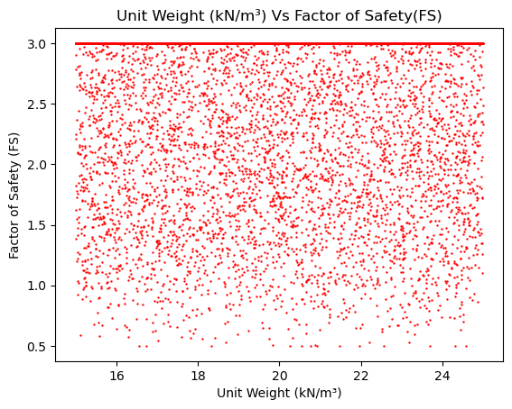

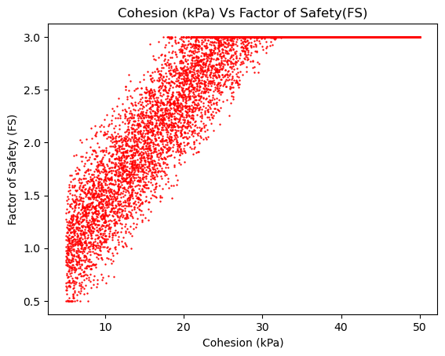

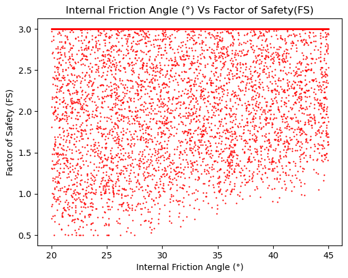

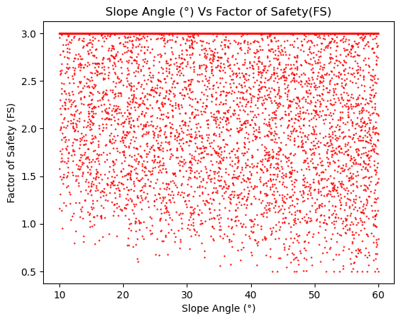

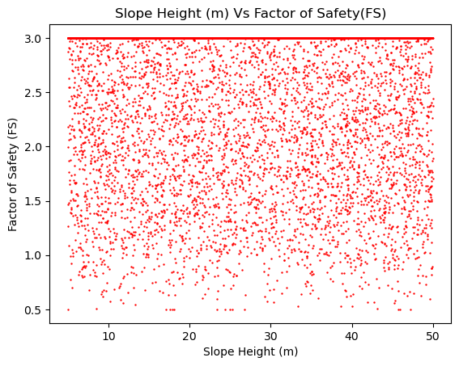

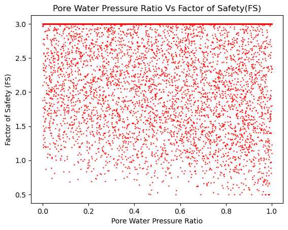

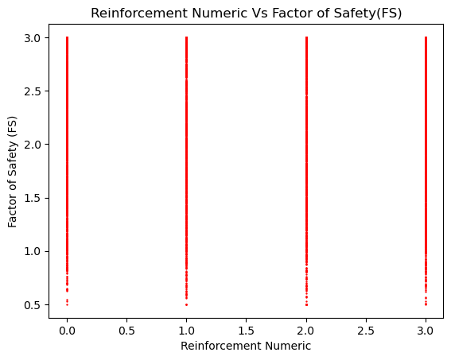

```python
for feature in features:
    plt.scatter(df[feature], df['Factor of Safety (FS)'], color="red", s=0.5)
    plt.xlabel(feature)
    plt.ylabel("Factor of Safety (FS)")
    plt.title(f"{feature} Vs Factor of Safety(FS)")
    plt.show()
```

## Features(Of Failed Slopes[marked in blue-red) Vs Factor of Safety (FS)

```python
ndf = df[df['Factor of Safety (FS)'] < 1]
ndf.head()
```

|  | Unit Weight (kN/m³) | Cohesion (kPa) | Internal Friction Angle (°) | Slope Angle (°) | Slope Height (m) | Pore Water Pressure Ratio | Reinforcement Type | Reinforcement Numeric | Factor of Safety (FS) |
| --- | --- | --- | --- | --- | --- | --- | --- | --- | --- |
| 21 | 16.394939 | 6.283401 | 27.995898 | 31.803031 | 49.796627 | 0.731507 | Geosynthetics | 2 | 0.877753 |
| 23 | 18.663618 | 5.370041 | 36.824104 | 43.903976 | 31.100451 | 0.668351 | Retaining Wall | 0 | 0.991259 |
| 47 | 20.200680 | 5.042437 | 24.892835 | 48.327669 | 33.736851 | 0.420834 | Soil Nailing | 1 | 0.640311 |
| 84 | 18.109823 | 6.442858 | 22.105336 | 35.216749 | 45.187696 | 0.942892 | Soil Nailing | 1 | 0.557517 |
| 134 | 24.429097 | 6.775338 | 21.577631 | 55.880894 | 48.754239 | 0.050395 | Drainage | 3 | 0.812782 |

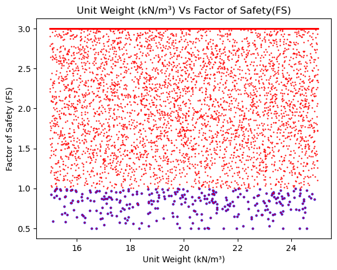

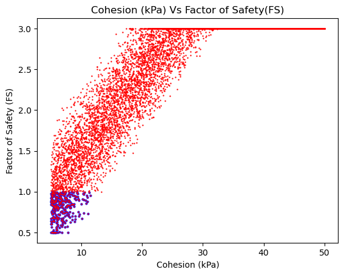

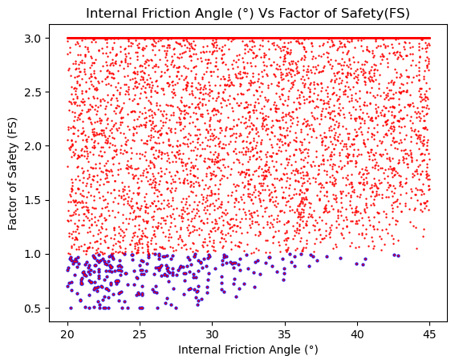

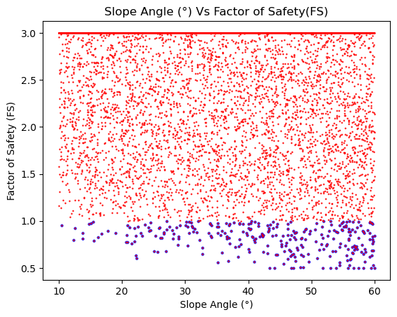

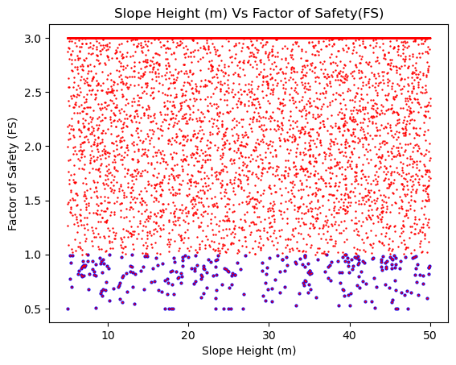

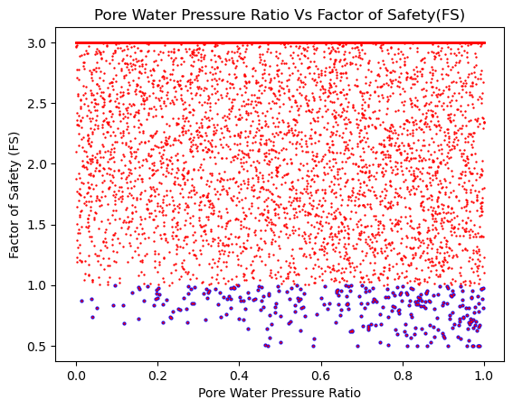

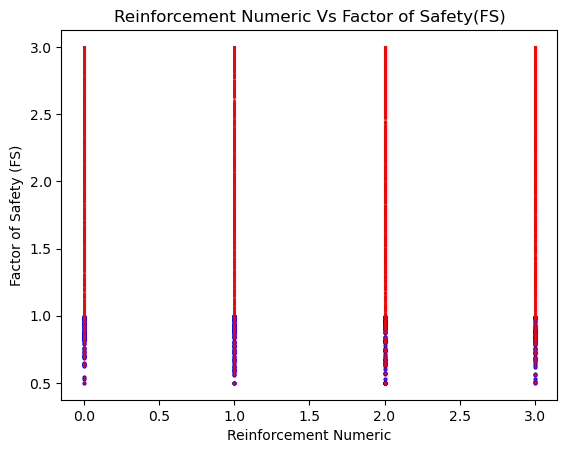

```python
for feature in features:
    plt.scatter(ndf[feature], ndf['Factor of Safety (FS)'], color="blue", s=4)
    plt.scatter(df[feature], df['Factor of Safety (FS)'], color="red", s=0.5)

    plt.xlabel(feature)
    plt.ylabel("Factor of Safety (FS)")
    plt.title(f"{feature} Vs Factor of Safety(FS)")
    plt.show()
```

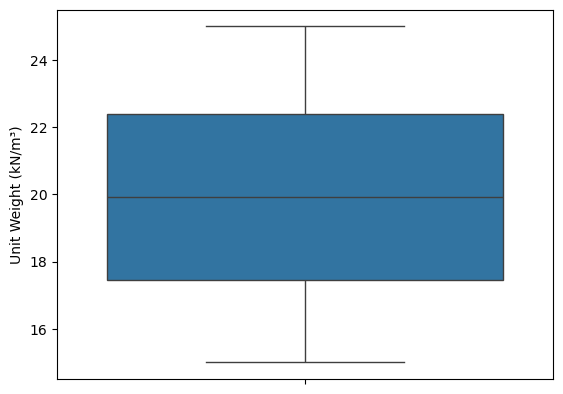

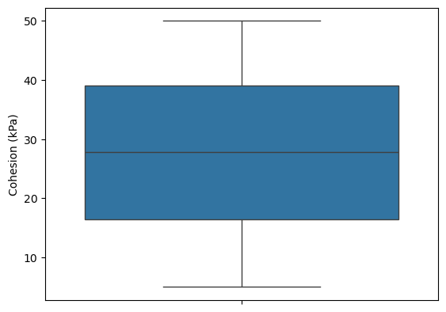

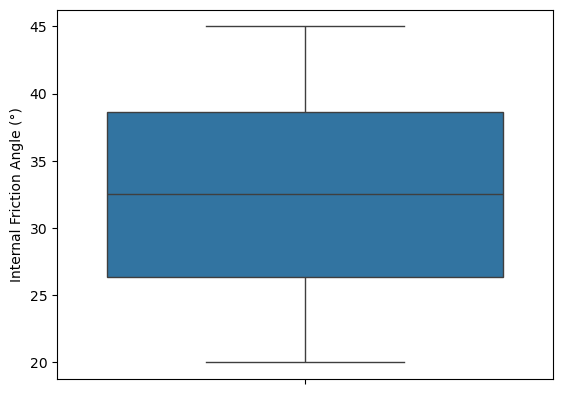

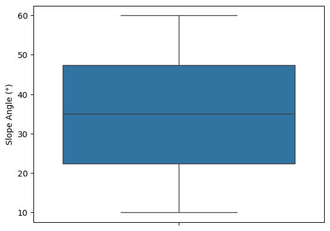

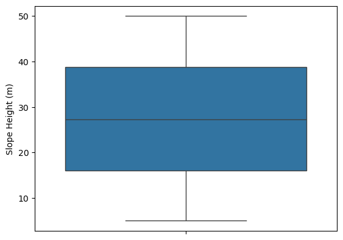

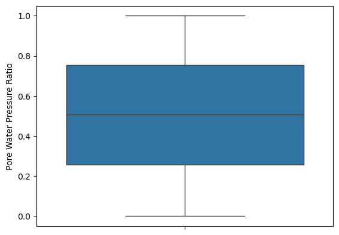

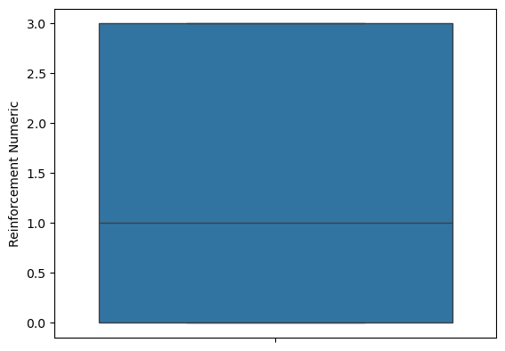

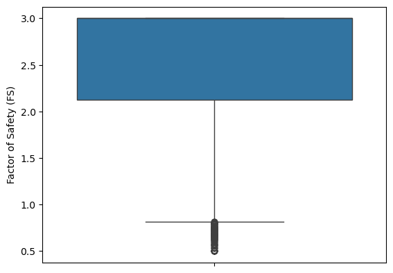

```python
for feature in features:
    sns.boxplot(df[feature])
    plt.show()
sns.boxplot(df['Factor of Safety (FS)'])
plt.show()
```

### Train Test Split

This code prepares the dataset for machine learning. First, we separates the data into **features** (`X`), which are the input variables used for prediction (like soil properties and slope geometry), and the **target** (`y`), which is the 'Factor of Safety' our model will learn to predict.

Then, the `train_test_split` function divides both `X` and `y` into two subsets: a **training set** (80% of the data) to build and train the model, and a **testing set** (the remaining 20%) to evaluate how well the trained model performs on new, unseen data. Using `random_state=42` ensures that the data is split in the exact same way every time the code is run, which is crucial for reproducible results.

```python
X = df[['Unit Weight (kN/m³)', 'Cohesion (kPa)','Internal Friction Angle (°)','Slope Angle (°)','Slope Height (m)','Pore Water Pressure Ratio', 'Reinforcement Numeric']]
y = df['Factor of Safety (FS)']
x_train, x_test, y_train, y_test = train_test_split(X,y, test_size = 0.2, random_state=42)
```

For this prediction task, I have implemented the **XGBoost (eXtreme Gradient Boosting)** algorithm, a powerful and popular choice for building high-performance predictive models.

```python
xmodel = XGBRegressor(n_estimators = 1000,
                      learning_rate = 0.05,
                      max_depth = 6,
                      subsample = 0.8,
                      random_state = 42)
```

```python
xmodel.fit(x_train, y_train)
```

```
XGBRegressor(base_score=None, booster=None, callbacks=None,
             colsample_bylevel=None, colsample_bynode=None,
             colsample_bytree=None, device=None, early_stopping_rounds=None,
             enable_categorical=False, eval_metric=None, feature_types=None,
             feature_weights=None, gamma=None, grow_policy=None,
             importance_type=None, interaction_constraints=None,
             learning_rate=0.05, max_bin=None, max_cat_threshold=None,
             max_cat_to_onehot=None, max_delta_step=None, max_depth=6,
             max_leaves=None, min_child_weight=None, missing=nan,
             monotone_constraints=None, multi_strategy=None, n_estimators=1000,
             n_jobs=None, num_parallel_tree=None, ...)
```

```python
y_pred = xmodel.predict(x_test)
y_pred = np.clip(y_pred, 0, 3)
```

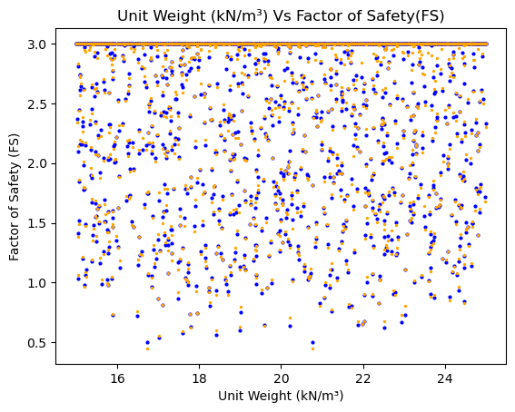

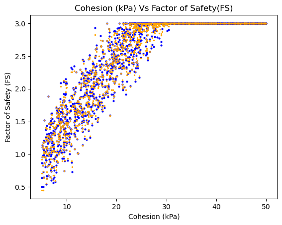

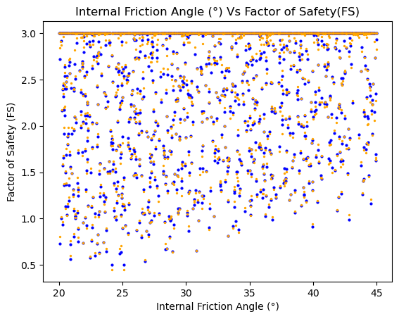

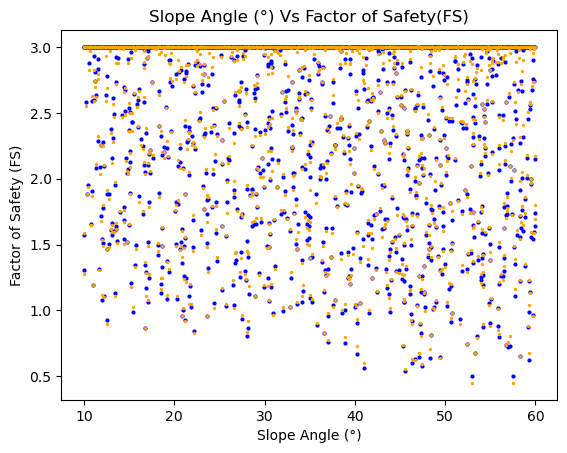

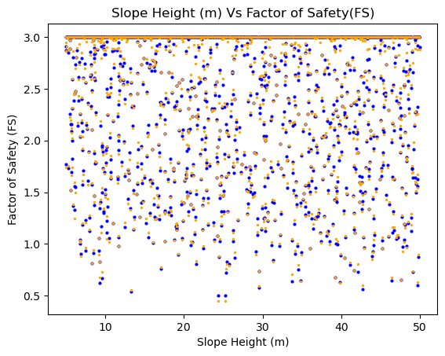

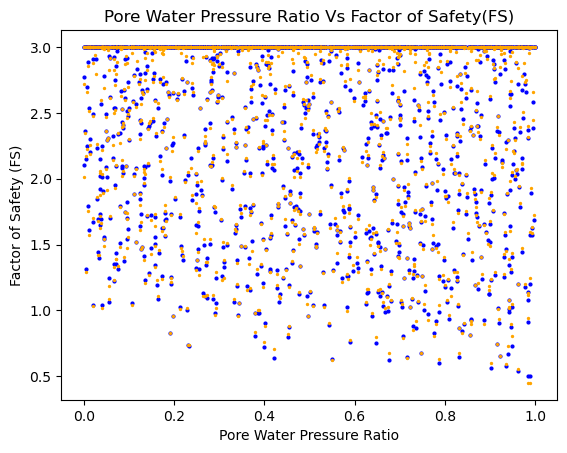

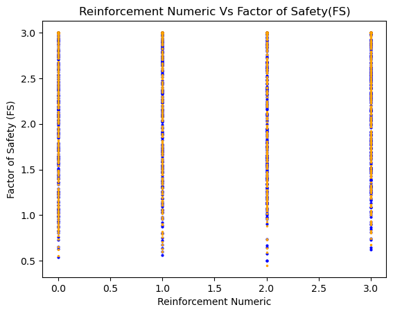

```python
for feature in features:
    plt.scatter(x_test[feature], y_test, color="blue", s=4)
    plt.scatter(x_test[feature], y_pred, color="orange", s=2)

    plt.xlabel(feature)
    plt.ylabel("Factor of Safety (FS)")
    plt.title(f"{feature} Vs Factor of Safety(FS)")
    plt.show()
```

Based on the exceptionally high R² score and negligible Mean Squared Error, our model predicts the outcome with outstanding accuracy and very little error.

```python
print("R2 Score:", r2_score(y_pred, y_test))
print("MSE:", mean_squared_error(y_pred, y_test))
```

```
R2 Score: 0.9986635395901442
MSE: 0.0005680387847458363
```

Commands to save and load the xgboost regressor model to a binary file.

```python
#xmodel.save_model("model.bin")
#xmodel.load_model("model.bin")
```